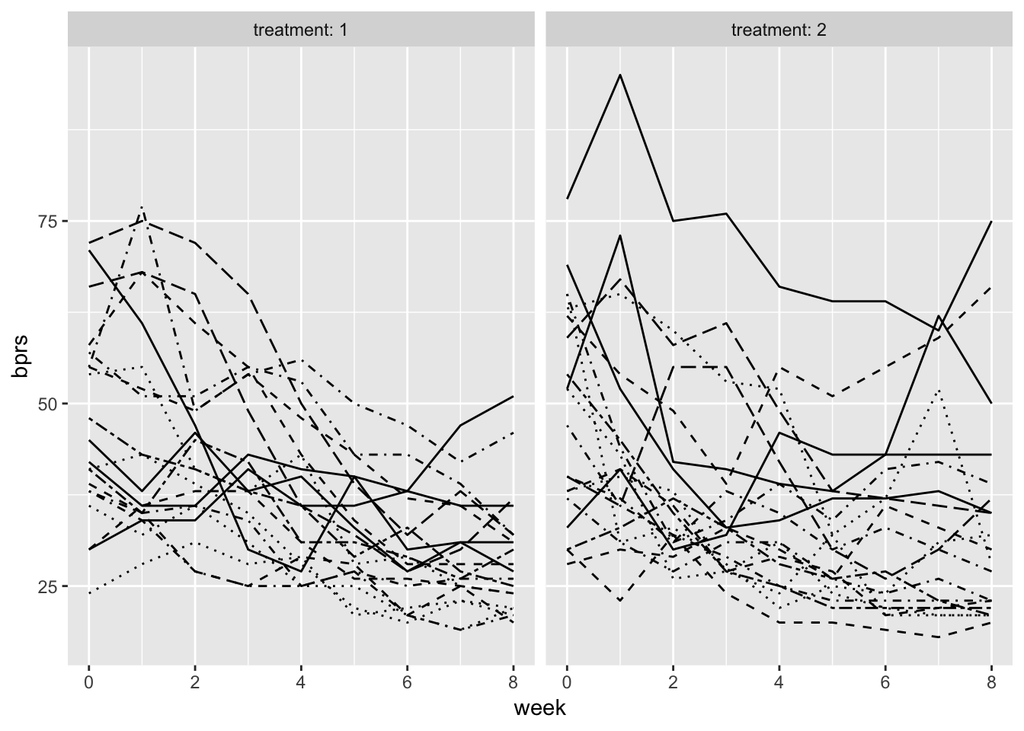

```r
chooseCRANmirror(graphics=FALSE, ind=1)
knitr::opts_chunk$set(echo = TRUE)
library(dplyr)
library(tidyr)
library(ggplot2)
BPRS<- read.table("https://raw.githubusercontent.com/KimmoVehkalahti/MABS/master/Examples/data/BPRS.txt", sep  =" ", header = T)
BPRS$treatment <- factor(BPRS$treatment)
BPRS$subject <- factor(BPRS$subject)
BPRSL <-  BPRS %>% gather(key = weeks, value = bprs, -treatment, -subject)
BPRSL <-  BPRSL %>% mutate(week = as.integer(substr(weeks,5,5)))
ggplot(BPRSL, aes(x = week, y = bprs, linetype = subject)) +
  geom_line() +
  scale_linetype_manual(values = rep(1:10, times=4)) +
  facet_grid(. ~ treatment, labeller = label_both) +
  theme(legend.position = "none") +
  scale_y_continuous(limits = c(min(BPRSL$bprs), max(BPRSL$bprs)))
```

The plot the BPRS score of almost all the men is decreasing over the eight weeks of the study.The men who have higher BPRS values at the beginning tend to have higher values throughout the study. There are substantial individual differences and variability appears to decrease with time.

```r
BPRSL <- BPRSL %>%
  group_by(week) %>%
  mutate(stdbprs = (bprs - mean(bprs))/sd(bprs) ) %>%
  ungroup()
glimpse(BPRSL)
```

```
## Observations: 360
## Variables: 6
## $ treatment <fct> 1, 1, 1, 1, 1, 1, 1, 1, 1, 1, 1, 1, 1, 1, 1, 1, 1, 1...
## $ subject   <fct> 1, 2, 3, 4, 5, 6, 7, 8, 9, 10, 11, 12, 13, 14, 15, 1...
## $ weeks     <chr> "week0", "week0", "week0", "week0", "week0", "week0"...
## $ bprs      <int> 42, 58, 54, 55, 72, 48, 71, 30, 41, 57, 30, 55, 36, ...
## $ week      <int> 0, 0, 0, 0, 0, 0, 0, 0, 0, 0, 0, 0, 0, 0, 0, 0, 0, 0...
## $ stdbprs   <dbl> -0.4245908, 0.7076513, 0.4245908, 0.4953559, 1.69836...
```

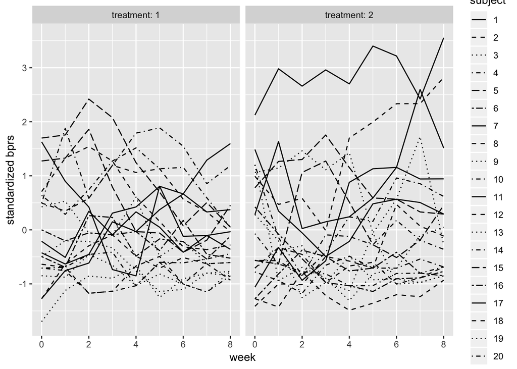

```r
ggplot(BPRSL, aes(x = week, y = stdbprs, linetype = subject)) +
  geom_line() +
  scale_linetype_manual(values = rep(1:10, times=4)) +
  facet_grid(. ~ treatment, labeller = label_both) +
  scale_y_continuous(name = "standardized bprs")
```

The standarised plot shows more clearly the tracking phenomenon.

```r
n <- BPRSL$week %>% unique() %>% length()
BPRSS <- BPRSL %>%
  group_by(treatment, week) %>%
  summarise( mean = mean(bprs), se = sd(bprs)/sqrt(n) ) %>%
  ungroup()
glimpse(BPRSS)
```

```
## Observations: 18
## Variables: 4
## $ treatment <fct> 1, 1, 1, 1, 1, 1, 1, 1, 1, 2, 2, 2, 2, 2, 2, 2, 2, 2
## $ week      <int> 0, 1, 2, 3, 4, 5, 6, 7, 8, 0, 1, 2, 3, 4, 5, 6, 7, 8
## $ mean      <dbl> 47.00, 46.80, 43.55, 40.90, 36.60, 32.70, 29.70, 29....
## $ se        <dbl> 4.534468, 5.173708, 4.003617, 3.744626, 3.259534, 2....
```

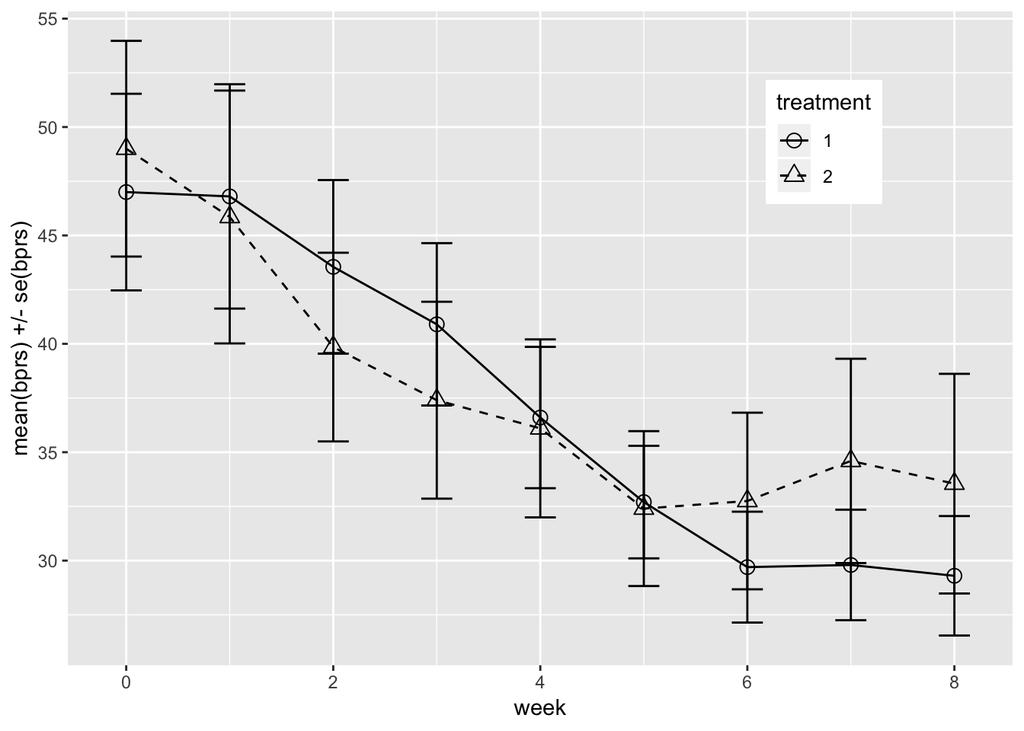

```r
ggplot(BPRSS, aes(x = week, y = mean, linetype = treatment, shape = treatment)) +
  geom_line() +
  scale_linetype_manual(values = c(1,2)) +
  geom_point(size=3) +
  scale_shape_manual(values = c(1,2)) +
  geom_errorbar(aes(ymin = mean - se, ymax = mean + se, linetype="1"), width=0.3) +
  theme(legend.position = c(0.8,0.8)) +
  scale_y_continuous(name = "mean(bprs) +/- se(bprs)")
```

The summary graph displays that both treatment groups’ BPRS values are decreasing in general. Treatment 2’s BPRS values however, rebounce after five weeks. The speed of decreasing BPRS values slows down in treament 1 after 6 weeks.

```r
BPRSL8S <- BPRSL %>%
  filter(week > 0) %>%
  group_by(treatment, subject) %>%
  summarise( mean=mean(bprs) ) %>%
  ungroup()
glimpse(BPRSL8S)
```

```
## Observations: 40
## Variables: 3
## $ treatment <fct> 1, 1, 1, 1, 1, 1, 1, 1, 1, 1, 1, 1, 1, 1, 1, 1, 1, 1...
## $ subject   <fct> 1, 2, 3, 4, 5, 6, 7, 8, 9, 10, 11, 12, 13, 14, 15, 1...
## $ mean      <dbl> 41.500, 43.125, 35.375, 52.625, 50.375, 34.000, 37.1...
```

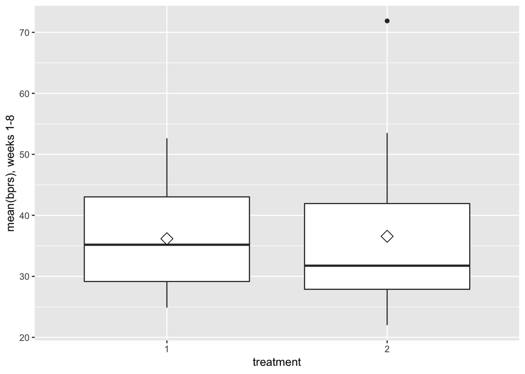

```r
ggplot(BPRSL8S, aes(x = treatment, y = mean)) +
  geom_boxplot() +
  stat_summary(fun.y = "mean", geom = "point", shape=23, size=4, fill = "white") +
  scale_y_continuous(name = "mean(bprs), weeks 1-8")
```

The diagram indicates that the mean summary measure is more variable in the second treatment group and its distribution in this group is somewhat skew. The boxplot of the second group reveals an outlier, a subject whose mean BPRS score of the eight weeks is over 70.

```r
BPRSL8S1 <- BPRSL8S %>%
  filter(mean < 60) %>%
  group_by(treatment, subject) %>%
  summarise(mean=mean(mean)) %>%
  ungroup()
glimpse(BPRSL8S1)
```

```
## Observations: 39
## Variables: 3
## $ treatment <fct> 1, 1, 1, 1, 1, 1, 1, 1, 1, 1, 1, 1, 1, 1, 1, 1, 1, 1...
## $ subject   <fct> 1, 2, 3, 4, 5, 6, 7, 8, 9, 10, 11, 12, 13, 14, 15, 1...
## $ mean      <dbl> 41.500, 43.125, 35.375, 52.625, 50.375, 34.000, 37.1...
```

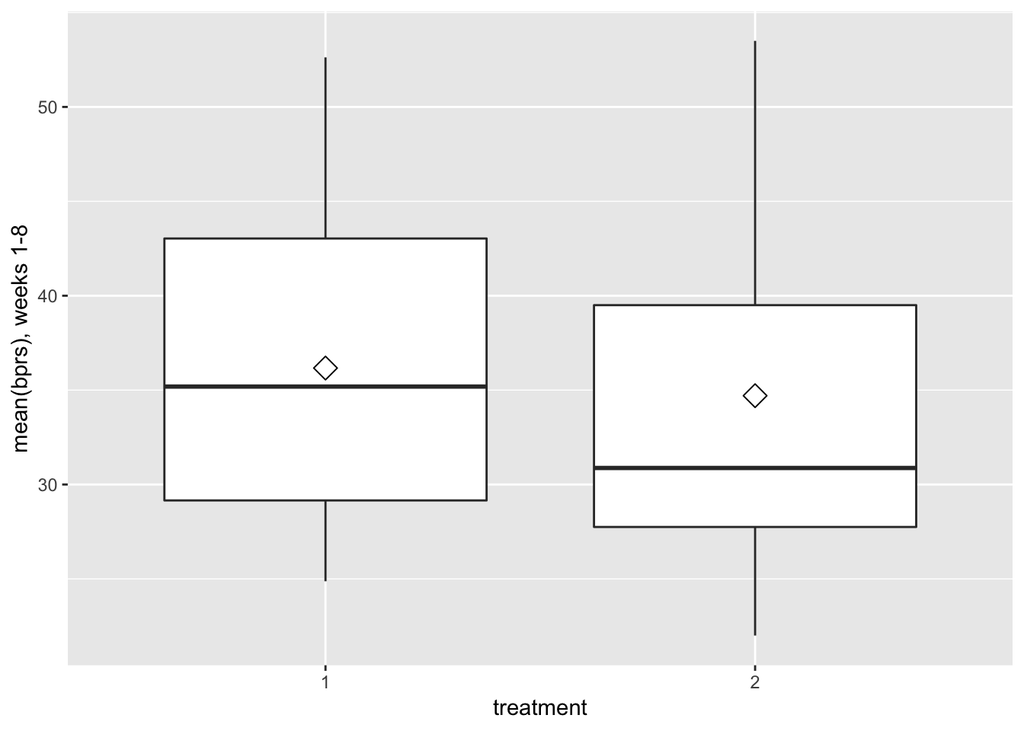

```r
ggplot(BPRSL8S1, aes(x = treatment, y = mean)) +
  geom_boxplot() +
  stat_summary(fun.y = "mean", geom = "point", shape=23, size=4, fill = "white") +
  scale_y_continuous(name = "mean(bprs), weeks 1-8")
```

After remove the outliner, the mean of the treatment 2 becomes smaller than treatment 1. We still cannot tell if the two treatment has significant difference.

```r
t.test(mean ~ treatment, data = BPRSL8S1, var.equal = TRUE)
```

```
##
##  Two Sample t-test
##
## data:  mean by treatment
## t = 0.52095, df = 37, p-value = 0.6055
## alternative hypothesis: true difference in means is not equal to 0
## 95 percent confidence interval:
##  -4.232480  7.162085
## sample estimates:
## mean in group 1 mean in group 2
##        36.16875        34.70395
```

```r
BPRSL8S2 <- BPRSL8S %>%
  mutate(baseline = BPRS$week0)
fit <- lm(mean ~ baseline + treatment, data = BPRSL8S2)
anova(fit)
```

```
## Analysis of Variance Table
##
## Response: mean
##           Df  Sum Sq Mean Sq F value    Pr(>F)
## baseline   1 1868.07 1868.07 30.1437 3.077e-06 ***
## treatment  1    3.45    3.45  0.0557    0.8148
## Residuals 37 2292.97   61.97
## ---
## Signif. codes:  0 '***' 0.001 '**' 0.01 '*' 0.05 '.' 0.1 ' ' 1
```

The t-test confirms the lack of any evidence for a group difference. Also the 95% confidence interval is wide and includes the zero, allowing for similar conclusions to be made.

#### Part2

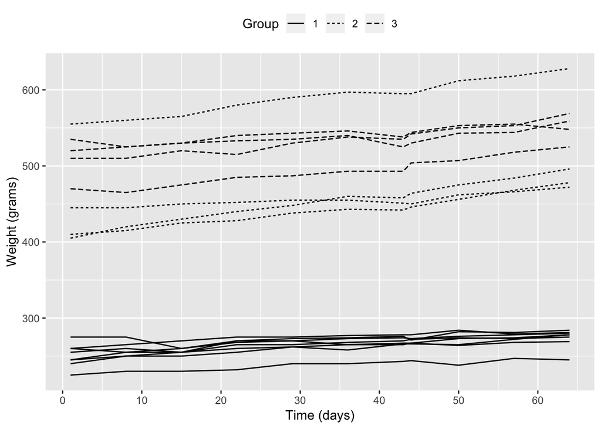

```r
RATS <- read.table("https://raw.githubusercontent.com/KimmoVehkalahti/MABS/master/Examples/data/rats.txt", sep = "", header = T)
RATS$Group <- factor(RATS$Group)
RATS$ID <- factor(RATS$ID)
RATSL <-  RATS %>% gather(key = WDs, value = Weight, -Group, -ID)
RATSL <-  RATSL %>% mutate(Time = as.integer(substr(WDs,3,4)))
ggplot(RATSL, aes(x = Time, y = Weight,group = ID)) +
  geom_line(aes(linetype = Group)) +
  scale_x_continuous(name = "Time (days)", breaks = seq(0, 60, 10)) +
  scale_y_continuous(name = "Weight (grams)") +
  theme(legend.position = "top")
```

This plot plots time and weight of the rats as three groups. Group1 seems to be clearly different (smaller weight) from other two groups.

```r
RATS_reg <- lm(Weight ~ Time + Group, data = RATSL)
summary(RATS_reg)
```

```
##
## Call:
## lm(formula = Weight ~ Time + Group, data = RATSL)
##
## Residuals:
##     Min      1Q  Median      3Q     Max
## -60.643 -24.017   0.697  10.837 125.459
##
## Coefficients:
##             Estimate Std. Error t value Pr(>|t|)
## (Intercept) 244.0689     5.7725  42.281  < 2e-16 ***
## Time          0.5857     0.1331   4.402 1.88e-05 ***
## Group2      220.9886     6.3402  34.855  < 2e-16 ***
## Group3      262.0795     6.3402  41.336  < 2e-16 ***
## ---
## Signif. codes:  0 '***' 0.001 '**' 0.01 '*' 0.05 '.' 0.1 ' ' 1
##
## Residual standard error: 34.34 on 172 degrees of freedom
## Multiple R-squared:  0.9283, Adjusted R-squared:  0.9271
## F-statistic: 742.6 on 3 and 172 DF,  p-value: < 2.2e-16
```

```r
library(lme4)
RATS_ref <- lmer(Weight ~ Time + Group + (1 | ID), data = RATSL, REML = FALSE)
summary(RATS_ref)
```

```
## Linear mixed model fit by maximum likelihood  ['lmerMod']
## Formula: Weight ~ Time + Group + (1 | ID)
##    Data: RATSL
##
##      AIC      BIC   logLik deviance df.resid
##   1333.2   1352.2   -660.6   1321.2      170
##
## Scaled residuals:
##     Min      1Q  Median      3Q     Max
## -3.5386 -0.5581 -0.0494  0.5693  3.0990
##
## Random effects:
##  Groups   Name        Variance Std.Dev.
##  ID       (Intercept) 1085.92  32.953
##  Residual               66.44   8.151
## Number of obs: 176, groups:  ID, 16
##
## Fixed effects:
##              Estimate Std. Error t value
## (Intercept) 244.06890   11.73107   20.80
## Time          0.58568    0.03158   18.54
## Group2      220.98864   20.23577   10.92
## Group3      262.07955   20.23577   12.95
##
## Correlation of Fixed Effects:
##        (Intr) Time   Group2
## Time   -0.090
## Group2 -0.575  0.000
## Group3 -0.575  0.000  0.333
```

The estimated variance of the rat random effects is quite large, indicating the considerable variation in the intercepts of the regression fits of the individual rat growth profiles.

```r
RATS_ref1 <- lmer(Weight ~ Time + Group + (Time | ID), data = RATSL, REML = FALSE)
summary(RATS_ref1)
```

```
## Linear mixed model fit by maximum likelihood  ['lmerMod']
## Formula: Weight ~ Time + Group + (Time | ID)
##    Data: RATSL
##
##      AIC      BIC   logLik deviance df.resid
##   1194.2   1219.6   -589.1   1178.2      168
##
## Scaled residuals:
##     Min      1Q  Median      3Q     Max
## -3.2261 -0.4322  0.0555  0.5638  2.8827
##
## Random effects:
##  Groups   Name        Variance  Std.Dev. Corr
##  ID       (Intercept) 1140.5363 33.7718
##           Time           0.1122  0.3349  -0.22
##  Residual               19.7456  4.4436
## Number of obs: 176, groups:  ID, 16
##
## Fixed effects:
##              Estimate Std. Error t value
## (Intercept) 246.45727   11.81526  20.859
## Time          0.58568    0.08548   6.852
## Group2      214.58736   20.17983  10.634
## Group3      258.92732   20.17983  12.831
##
## Correlation of Fixed Effects:
##        (Intr) Time   Group2
## Time   -0.166
## Group2 -0.569  0.000
## Group3 -0.569  0.000  0.333
```

```r
anova(RATS_ref1, RATS_ref)
```

```
## Data: RATSL
## Models:
## RATS_ref: Weight ~ Time + Group + (1 | ID)
## RATS_ref1: Weight ~ Time + Group + (Time | ID)
##           Df    AIC    BIC  logLik deviance  Chisq Chi Df Pr(>Chisq)
## RATS_ref   6 1333.2 1352.2 -660.58   1321.2
## RATS_ref1  8 1194.2 1219.6 -589.11   1178.2 142.94      2  < 2.2e-16 ***
## ---
## Signif. codes:  0 '***' 0.001 '**' 0.01 '*' 0.05 '.' 0.1 ' ' 1
```

```r
RATS_ref2 <- lmer(Weight ~ Time * Group + (Time | ID), data = RATSL, REML = FALSE)
summary(RATS_ref2)
```

```
## Linear mixed model fit by maximum likelihood  ['lmerMod']
## Formula: Weight ~ Time * Group + (Time | ID)
##    Data: RATSL
##
##      AIC      BIC   logLik deviance df.resid
##   1185.9   1217.6   -582.9   1165.9      166
##
## Scaled residuals:
##     Min      1Q  Median      3Q     Max
## -3.2669 -0.4249  0.0726  0.6034  2.7513
##
## Random effects:
##  Groups   Name        Variance  Std.Dev. Corr
##  ID       (Intercept) 1.107e+03 33.2763
##           Time        4.925e-02  0.2219  -0.15
##  Residual             1.975e+01  4.4436
## Number of obs: 176, groups:  ID, 16
##
## Fixed effects:
##              Estimate Std. Error t value
## (Intercept) 251.65165   11.80279  21.321
## Time          0.35964    0.08215   4.378
## Group2      200.66549   20.44303   9.816
## Group3      252.07168   20.44303  12.330
## Time:Group2   0.60584    0.14229   4.258
## Time:Group3   0.29834    0.14229   2.097
##
## Correlation of Fixed Effects:
##             (Intr) Time   Group2 Group3 Tm:Gr2
## Time        -0.160
## Group2      -0.577  0.092
## Group3      -0.577  0.092  0.333
## Time:Group2  0.092 -0.577 -0.160 -0.053
## Time:Group3  0.092 -0.577 -0.053 -0.160  0.333
```

```r
anova(RATS_ref2, RATS_ref1)
```

```
## Data: RATSL
## Models:
## RATS_ref1: Weight ~ Time + Group + (Time | ID)
## RATS_ref2: Weight ~ Time * Group + (Time | ID)
##           Df    AIC    BIC  logLik deviance  Chisq Chi Df Pr(>Chisq)
## RATS_ref1  8 1194.2 1219.6 -589.11   1178.2
## RATS_ref2 10 1185.9 1217.6 -582.93   1165.9 12.361      2    0.00207 **
## ---
## Signif. codes:  0 '***' 0.001 '**' 0.01 '*' 0.05 '.' 0.1 ' ' 1
```

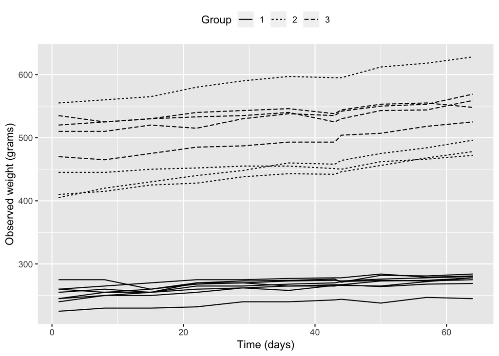

```r
ggplot(RATSL, aes(x = Time, y = Weight, group = ID)) +
  geom_line(aes(linetype = Group)) +
  scale_x_continuous(name = "Time (days)", breaks = seq(0, 60, 20)) +
  scale_y_continuous(name = "Observed weight (grams)") +
  theme(legend.position = "top")
```

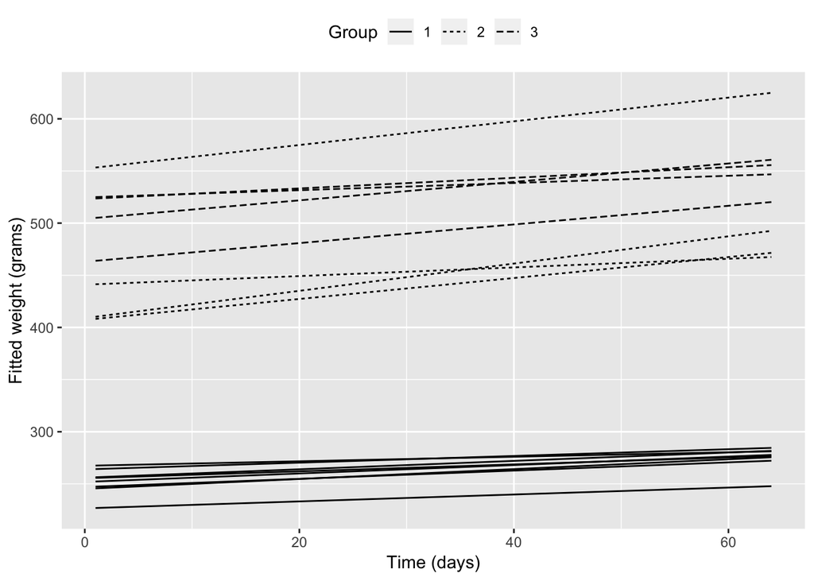

```r
Fitted <- fitted(RATS_ref2)
RATSL <- RATSL %>%
  mutate(Fitted)
ggplot(RATSL, aes(x = Time, y = Fitted, group = ID)) +
  geom_line(aes(linetype = Group)) +
  scale_x_continuous(name = "Time (days)", breaks = seq(0, 60, 20)) +
  scale_y_continuous(name = "Fitted weight (grams)") +
  theme(legend.position = "top")
```